# Movie Recommender - Twitter and MovieLens

N Obi-Eyisi & N Nedd

# Our Project

In response to a tweet reviewing a movie, recommend a movie based on:

- ratings in the MovieLens Database
- overall twitter reviews of the initial movie

# Data Sources

- Twitter feed @FilmReviewIn140 : for initial tweets

[figure not shown]

# Data Sources

- General twitter search (I rated ‘movie-name’ #imdb)

[figure not shown]

# Data Sources

- Standford’s large movie review dataset (http://ai.stanford.edu/~amaas/data/sentiment/) : to train sentiment analysis model

– several text files identifed as positive or negative movie reviews

- Movielens large database (https://grouplens.org/datasets/movielens/): to select the top 10 rated movies (based on genre)

– multiple zipped csv files (for project used movies and ratings)

# Process

The process to Recommend was as follows:

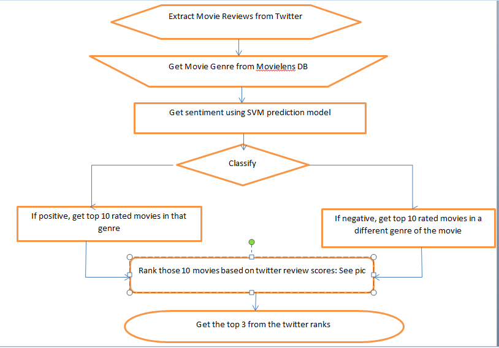

# Results - Sentiment Analysis

- Tested Accuracy against the letter grade assigned to each review
- Achieved 75% accuracy

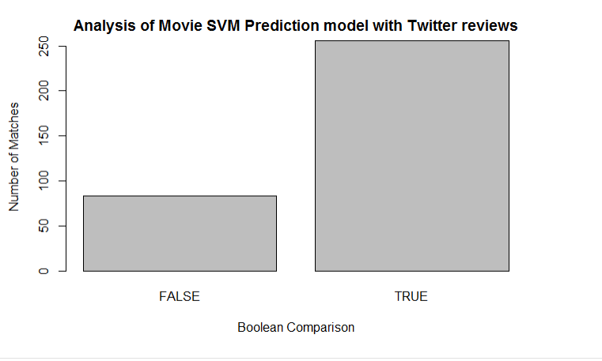

# Result - Recommendation

Godzilla (2014) had negative sentiment and is tagged with the following genres: Action|Adventure|Sci-Fi|IMAX

gave rise to the following selections from movielens database:

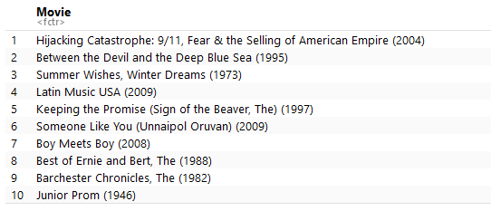

# Result - Recommendation

And the top 3 with respect to twitter popularity were:

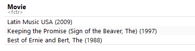

# Another Result - Recommendation

Olympus Has Fallen had a positive sentiment and is tagged with the following genres: Action|Thriller

gave rise to the following selections from the movielens database:

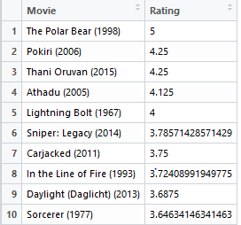

# Another Result - Recommendation

And the top 3 with respect to twitter popularity were:

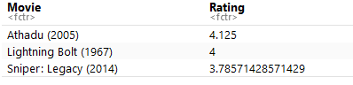

# Challenges

- How to analyse sentiment?

– Solved by using additional dataset maintained by Standford University to train a prediction model

- How to find tweets with reviews?

– Solved by using a particular twitter handle which had tweets in particular format

– For choosing top three searched for particular phrasing of “I rated movie #imdb”

- For general searches twitter API only gives access to tweets going back one week.

# Conclusion

- Project enabled an exploration of recommendation systems where not much is known about the person recommending to (other than one tweet).
- Project helped to understand how to get data from twitter
- Project allowed exploration of text analysis including sentiment analysis
- Further improvements include analysing additional meta data about the movie such as Directors, Actors, Producers, and even plot analysis for bettter recommendation

# Questions

THANK YOU